# R Notebook

Existem diversas aplicações que não se beneficiam das caches. Quando são executadas normalmente, causam poluição de cache para as outras aplicações rodando simultaneamente e consomem energia desnecessariamente, tanto por fazer uso da cache quando não há necessidade quanto por causar slowdown das outras aplicações, fazendo o processador ficar ativo por mais tempo, além de causar mais acessos à memória devido a poluição de cache, que consomem energia.

Podemos observar primeiramente o slowdown em uma thread de um microbenchmark que faz leitura e acumulação de um vetor que cabe confortavelmente na cache quando é executado simultaneamente a uma outra thread do mesmo benchrmark.

Primeiro um código pra carregar os resultados em um dataframe:

```r
library(dplyr)
library(tidyr);
df <- read.csv("../expmat/outputs/08.07.10.mitt.csv");
k <- df %>% select(sizea,sizeb,temp,cyca,l3ma,l3ra,cycb,l3mb,l3rb) %>%
 group_by(sizea,sizeb,temp) %>% summarise(mcyca=min(cyca), ml3ma=min(l3ma), ml3ra=min(l3ra), mcycb=min(cycb), ml3mb=min(l3mb), ml3rb=min(l3rb), .groups='drop') %>%  as.data.frame()
k2 <- k;
k2$sizea = k$sizeb; k2$sizeb = k$sizea; k2$mcyca = k$mcycb; k2$mcycb = k$mcyca;
k2$ml3ra = k$ml3rb; k2$ml3rb = k$ml3ra; k2$ml3ma = k$ml3mb; k2$ml3mb = k$ml3ma;
k2$temp <- replace(as.character(k2$temp), k2$temp == "nt","tmp")
k2$temp <- replace(as.character(k2$temp), k2$temp == "tn","nt")
k2$temp <- replace(as.character(k2$temp), k2$temp == "tmp","tn")
combined <- rbind(k,k2)
k <- subset( combined, select = -c(mcycb,ml3rb,ml3mb));
k <- k %>% group_by(sizea,sizeb,temp,) %>% summarise( mcyca=mean(mcyca), ml3ra=mean(ml3ra), ml3ma=mean(ml3ma), .groups='drop');
k <- k %>% rename (cyc = mcyca, l3r = ml3ra, l3m = ml3ma)
k <- k[k$sizea!=0,]
k <- k %>% mutate(sizea = sizea/1024, sizeb = sizeb/1024)
rm(combined, k2)
head(k)
```

```
## # A tibble: 6 x 6
##   sizea sizeb temp           cyc         l3r     l3m
##   <dbl> <dbl> <chr>        <dbl>       <dbl>   <dbl>
## 1     1     0 nn    26192683123         105      0
## 2     1     0 nt    26235417668          86      2
## 3     1     0 tn     5030942956  1048576997  17171
## 4     1     0 tt     5030948036  1048577042  17159
## 5     1     1 nn    27616080778         132.     6
## 6     1     1 nt    26274811372.        138.     2.5
```

Agora observando a diferença na quantidade de ciclos para executar o benchmark com 4 MB sozinho ou com outra thread lendo 256 MB simultaneamente.

```r
k[k$temp=="tt" & k$sizea==4 & ( k$sizeb==256 | k$sizeb==0 ),]
```

```
## # A tibble: 2 x 6
##   sizea sizeb temp         cyc        l3r    l3m
##   <dbl> <dbl> <chr>      <dbl>      <dbl>  <dbl>
## 1     4     0 tt    5003381051 1042188976  73568
## 2     4   256 tt    5112801442 1042192098 107349
```

A diferença aparentemente é bem pequena. Quem sabe observando com uma aplicação que caiba com menos folga na cache, como 7MB.

```r
k[k$temp=="tt" & k$sizea==7 & ( k$sizeb==256 | k$sizeb==0 ),]
```

```
## # A tibble: 2 x 6
##   sizea sizeb temp         cyc        l3r     l3m
##   <dbl> <dbl> <chr>      <dbl>      <dbl>   <dbl>
## 1     7     0 tt    5434646021 1126152998  182711
## 2     7   256 tt    5760873248 1126154169 8592174
```

A diferença é pequena também. Quem sabe 8 MB então?

```r
k[k$temp=="tt" & k$sizea==8 & ( k$sizeb==256 | k$sizeb==0 ),]
```

```
## # A tibble: 2 x 6
##   sizea sizeb temp         cyc       l3r      l3m
##   <dbl> <dbl> <chr>      <dbl>     <dbl>    <dbl>
## 1     8     0 tt    4813527640 919308648 10202847
## 2     8   256 tt    6521674824 919327185 84604598
```

Nesse caso realmente com a thread de 256 MB há um slowdown significativo.

De quanto?

Adicionando colunas para as diferenças conforme sizeb aumenta para todos sizea:

```r
#k <- k %>% group_by(sizea,temp) %>% mutate_each(funs(./.[1]), cyc_diff=cyc, l3r_diff=l3r, l3m_diff=l3m, -sizeb)
k_diff <- k %>% group_by(sizea) %>% mutate_each(funs(./.[4]), cyc_diff=cyc, l3r_diff=l3r, l3m_diff=l3m, -sizeb)
# CUIDADO!! GAMBIARRA ESSE [4]
k_diff # %>% filter(temp=="nt")# %>% head()
```

```
## # A tibble: 840 x 9
## # Groups:   sizea [14]
##    sizea sizeb temp          cyc        l3r     l3m cyc_diff   l3r_diff l3m_diff
##    <dbl> <dbl> <chr>       <dbl>      <dbl>   <dbl>    <dbl>      <dbl>    <dbl>
##  1     1     0 nn        2.62e10     1.05e2     0       5.21    1.00e-7 0
##  2     1     0 nt        2.62e10     8.60e1     2       5.21    8.20e-8 0.000117
##  3     1     0 tn        5.03e 9     1.05e9 17171       1.00    1.00e+0 1.00
##  4     1     0 tt        5.03e 9     1.05e9 17159       1       1.00e+0 1
##  5     1     1 nn        2.76e10     1.32e2     6       5.49    1.26e-7 0.000350
##  6     1     1 nt        2.63e10     1.38e2     2.5     5.22    1.32e-7 0.000146
##  7     1     1 tn        5.08e 9     1.05e9 17195       1.01    1.00e+0 1.00
##  8     1     1 tt        5.10e 9     1.05e9 17160       1.01    1.00e+0 1.00
##  9     1     2 nn        2.81e10     1.47e2     2       5.58    1.40e-7 0.000117
## 10     1     2 nt        2.63e10     1.62e2     7       5.23    1.54e-7 0.000408
## # ... with 830 more rows
```

Visualizando os valores para sizea = 8 MB

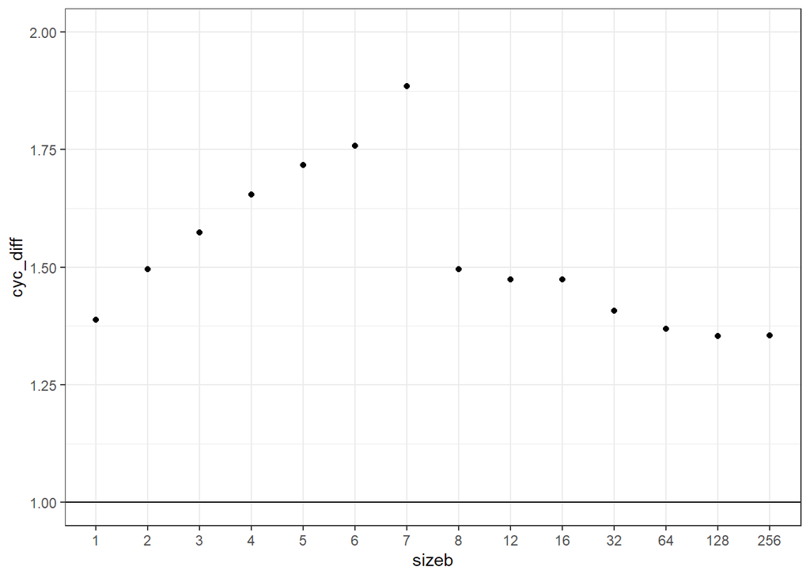

```r
library(ggplot2)
k_diff %>% filter(sizea==8, temp == "tt", sizeb!=0) %>% ungroup() %>% select(sizeb,cyc_diff) %>% ggplot(aes(x=as.factor(sizeb), y=cyc_diff)) + geom_point() +
   theme_bw() + xlab("sizeb") + ylim(1,2) + geom_hline(yintercept=1)
```

Percebe-se que uma outra aplicação que acessa a memória causa um impacto negativo no desempenho que aumenta conforme o uso de memória dessa aplicação aumenta, até que ela atinge o tamanho da cache ou o tamanho da primeira aplicação.

A aplicação que usa menos memória faz acessos mais frequentes a cache, de certa forma se apropriando da cache devido a política de substituição dar prioridade às linhas mais recentemente acessadas.

Talvez por esse motivo as aplicaçÕes maiores não interfiram tanto, porque a aplicação menor faz acessos mais frequentes e consegue manter seu dataset na cache. Um teste interessante seria colocar um delay entre os acessos da aplicação pequena, próximo a latência de acesso a DRAM, para que tanto a aplicação que usa cache quanto a que não use exerçam a mesma pressão na cache. Isso também representaria melhor uma apresentação real, que lê os dados e faz alguma coisa com eles além de acumular o valor.

Podemos observar o impacto na outra aplicação devido a essa aplicação que usa 8 MB.

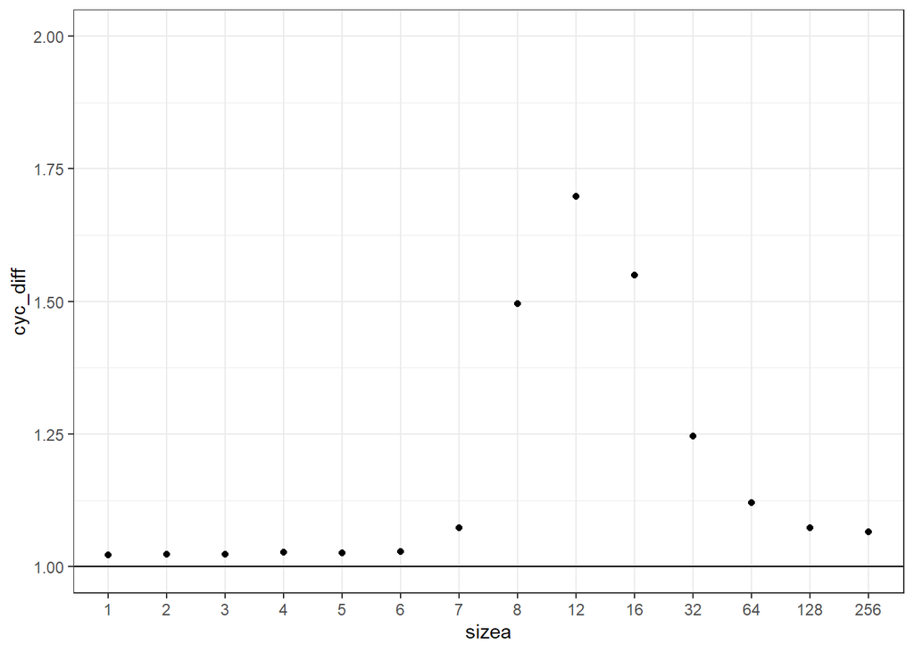

```r
k_diff %>% filter(sizeb==8, temp == "tt") %>% ungroup() %>% select(sizea,cyc_diff) %>% ggplot(aes(x=as.factor(sizea), y=cyc_diff)) + geom_point() +
   theme_bw() + xlab("sizea") + ylim(1,2) + geom_hline(yintercept=1)
```

E o que acontece com a aplicação de 8 MB se a aplicação concorrente utilizar loads não temporais?

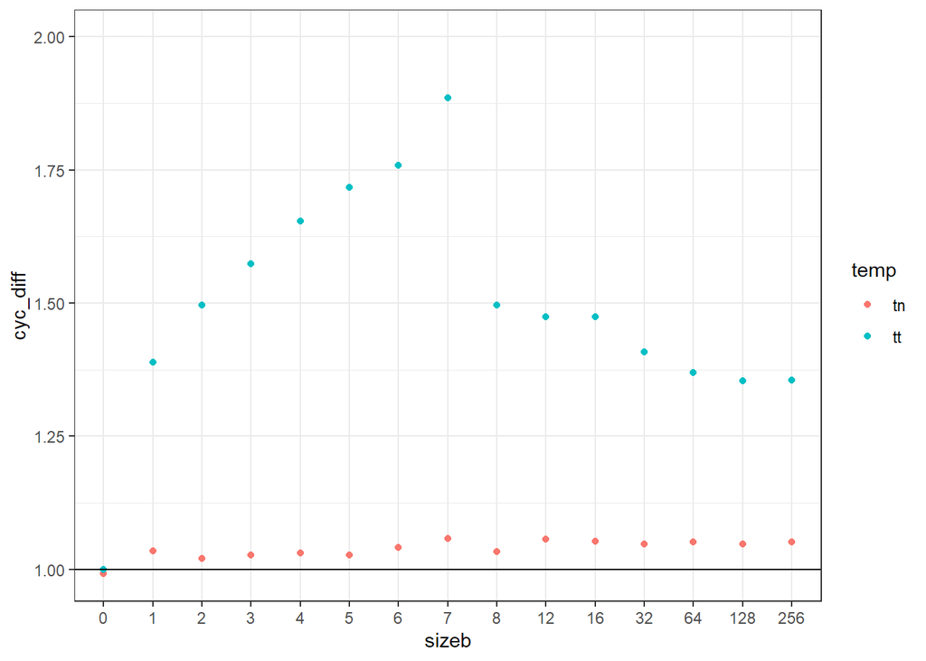

```r
k_diff %>% filter(sizea==8, temp == "tt" | temp == "tn") %>% ungroup() %>% select(sizeb,cyc_diff,temp) %>% ggplot(aes(x=as.factor(sizeb), y=cyc_diff, color=temp)) + geom_point() +
   theme_bw() + xlab("sizeb") + ylim(0.99,2) + geom_hline(yintercept=1)
```

Legal, o desempenho da primeira aplicação quase sempre retorna ao normal quando a segunda aplicação passa a utilizar loads não temporais. Não retorna totalmente ao valor original porque ainda há alguma concorrência por hardware mesmo que não contamine a cache.

Mas o problema é que a aplicação secundária perde muito desempenho ao utilizar os loads não temporais.

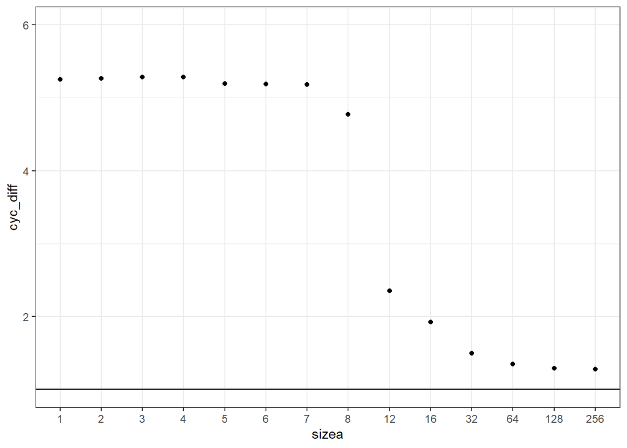

```r
k_diff %>% filter(sizeb==8, temp == "nt") %>% ungroup() %>% select(sizea,cyc_diff) %>% ggplot(aes(x=as.factor(sizea), y=cyc_diff)) + geom_point() +
   theme_bw() + xlab("sizea") + ylim(1,6) + geom_hline(yintercept=1)
```

Piora bastante para os valores que cabem na cache. Para 16 MB, o dobro da cache, piora quase 2 vezes, e para valores maiores piora um pouco. Quanto exatamente?

```r
k_diff %>% filter(sizea==256,sizeb==8,temp=="nt") %>% ungroup() %>% select(cyc_diff) %>% as.numeric()
```

```
## [1] 1.277858
```

27.78%

A aplicação de 256 MB sozinha perde quanto por usar loads não temporais?

```r
k_diff %>% filter(sizea==256,sizeb==0,temp=="nt") %>% ungroup() %>% select(cyc_diff) %>% as.numeric()
```

```
## [1] 1.254393
```

Perde 25.4%. Podemos concluir então que nessa máquina os loads não temporais possuem uma largura de banda 25.4% menor, ou algo próximo disso. Um problema dos testes é que eles não fazem só loads mas load e acumulação. Também não leva em conta o prefetcher que existe e melhora o desempenho.

É estranho porque os outros experimentos mostraram que a latência dos loads não temporais é só 6.3% pior.

Voltando ao assunto que importa, como a soma dos ciclos das aplicaçÕes muda conforme os loads mudam de temporal pra não temporal?

Provavelmente tem um jeito de fazer isso com uma linha em R mas como não sei vou fazer uma gambiarra.

Primeiro vou gerar um dataframe invertido, onde a aplicação A e B do dataframe original são invertidas.

```r
ktemp <- k %>% filter(sizeb != 0);
k_inv <- ktemp;
k_inv$sizea = ktemp$sizeb
k_inv$sizeb = ktemp$sizea
k_inv$temp <- replace(as.character(k_inv$temp), k_inv$temp == "nt","tmp")
k_inv$temp <- replace(as.character(k_inv$temp), k_inv$temp == "tn","nt")
k_inv$temp <- replace(as.character(k_inv$temp), k_inv$temp == "tmp","tn")
rm(ktemp)
```

Aí juntar os dois dataframes e somar as linhas com fatores iguais.

```r
k_sum <- rbind(k,k_inv)
k_sum <- k_sum %>% group_by(sizea,sizeb,temp) %>% summarise(cyc=sum(cyc), l3m=sum(l3m), l3r=sum(l3r), .groups='drop')
rm(k_inv)
head(k_sum)
```

```
## # A tibble: 6 x 6
##   sizea sizeb temp          cyc    l3m        l3r
##   <dbl> <dbl> <chr>       <dbl>  <dbl>      <dbl>
## 1     1     0 nn    26192683123     0         105
## 2     1     0 nt    26235417668     2          86
## 3     1     0 tn     5030942956 17171  1048576997
## 4     1     0 tt     5030948036 17159  1048577042
## 5     1     1 nn    55232161556    12         265
## 6     1     1 nt    31354854232 17198. 1048577109
```

Agora gerando um dataframe com a diferença de ciclos para esse dataframe

```r
#k <- k %>% group_by(sizea,temp) %>% mutate_each(funs(./.[1]), cyc_diff=cyc, l3r_diff=l3r, l3m_diff=l3m, -sizeb)
k_sum_diff <- k_sum %>% group_by(sizea) %>% mutate_each(funs(./.[4]), cyc_diff=cyc, l3r_diff=l3r, l3m_diff=l3m, -sizeb)
# CUIDADO!! GAMBIARRA ESSE [4]

head(k_sum_diff)
```

```
## # A tibble: 6 x 9
## # Groups:   sizea [1]
##   sizea sizeb temp          cyc    l3m        l3r cyc_diff     l3r_diff l3m_diff
##   <dbl> <dbl> <chr>       <dbl>  <dbl>      <dbl>    <dbl>        <dbl>    <dbl>
## 1     1     0 nn    26192683123     0         105     5.21 0.000000100  0
## 2     1     0 nt    26235417668     2          86     5.21 0.0000000820 0.000117
## 3     1     0 tn     5030942956 17171  1048576997     1.00 1.00         1.00
## 4     1     0 tt     5030948036 17159  1048577042     1    1            1
## 5     1     1 nn    55232161556    12         265    11.0  0.000000253  0.000699
## 6     1     1 nt    31354854232 17198. 1048577109     6.23 1.00         1.00
```

E o gráfico da diferença entre a soma dos ciclos para a aplicação A com tamanho de 8 MB e loads temporais e a aplicação B com loads temporais ou não temporais para todos os tamanhos.

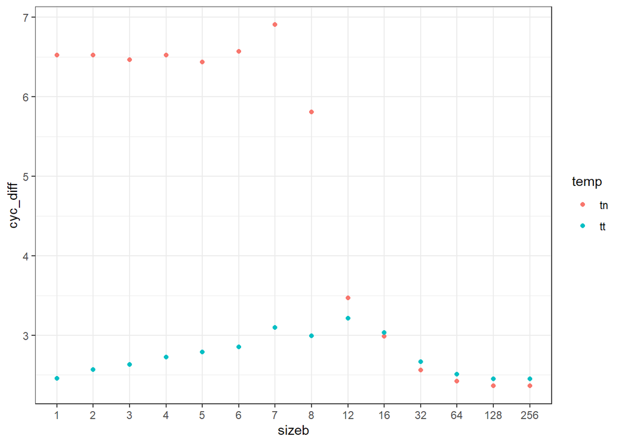

```r
k_sum_diff %>% filter(sizea==8, temp == "tt" | temp == "tn") %>% ungroup() %>% filter(sizeb!=0) %>% select(sizeb,cyc_diff,temp) %>% ggplot(aes(x=as.factor(sizeb), y=cyc_diff, color=temp)) + geom_point() +
   theme_bw() + xlab("sizeb")# + geom_hline(yintercept=1)
```

Percebe-se que para tamanhos da aplicação B de até 12 MB, o desempenho agregado das aplicações é piorado por utilizar loads não temporais na aplicação B. Para valores maiores, há algum ganho. Parece que o ganho é maior com a aplicação B em 32 MB.

```r
k_sum %>% group_by(sizea,sizeb) %>% mutate_each(funs(./.[4]), -temp) %>% filter(sizeb > 16, sizea==8, temp=="tn")
```

```
## # A tibble: 4 x 6
## # Groups:   sizea, sizeb [4]
##   sizea sizeb temp    cyc    l3m   l3r
##   <dbl> <dbl> <chr> <dbl>  <dbl> <dbl>
## 1     8    32 tn    0.960 0.0291 0.760
## 2     8    64 tn    0.965 0.0375 0.778
## 3     8   128 tn    0.964 0.0341 0.785
## 4     8   256 tn    0.965 0.0363 0.785
```

```r
#novamente gambiarra pra normalizar pela temporalidade tt
```

Os dados mostram que com a aplicação A de 8 MB e a aplicação B de 32 MB, quando a aplicação B usa loads não temporais, a soma dos ciclos de ambas é 96% da soma dos ciclos quando ambas usam loads temporais.

Em que casos há mais ganho?

```r
k_sum %>% group_by(sizea,sizeb) %>% mutate_each(funs(./.[4]), -temp) %>% filter(temp=="tn") %>% arrange(cyc) %>% head(10)
```

```
## # A tibble: 10 x 6
## # Groups:   sizea, sizeb [10]
##    sizea sizeb temp    cyc    l3m   l3r
##    <dbl> <dbl> <chr> <dbl>  <dbl> <dbl>
##  1     8    32 tn    0.960 0.0291 0.760
##  2     8   128 tn    0.964 0.0341 0.785
##  3     8    64 tn    0.965 0.0375 0.778
##  4     8   256 tn    0.965 0.0363 0.785
##  5     8    16 tn    0.986 0.0275 0.712
##  6     8     0 tn    0.992 0.862  1.00
##  7    32     0 tn    0.999 1.00   1.00
##  8    12     0 tn    1.00  1.00   1.00
##  9   256     0 tn    1.00  1.00   1.00
## 10   128     0 tn    1.00  1.00   1.00
```

Parece que só pra esses casos mesmo da aplicação A com 8 MB… Estranho.

```r
k %>% filter(sizea==12, sizeb==256)
```

```
## # A tibble: 4 x 6
##   sizea sizeb temp          cyc       l3r       l3m
##   <dbl> <dbl> <chr>       <dbl>     <dbl>     <dbl>
## 1    12   256 nn    11653819198       653         2
## 2    12   256 nt    11881340215    113180    112076
## 3    12   256 tn     5315134853 462946106 181492483
## 4    12   256 tt     5877529299 462951439 210380194
```

```r
k %>% filter(sizeb==12, sizea==256)
```

```
## # A tibble: 4 x 6
##   sizea sizeb temp         cyc       l3r       l3m
##   <dbl> <dbl> <chr>      <dbl>     <dbl>     <dbl>
## 1   256    12 nn    6440536052    479153       100
## 2   256    12 nt    6451173345    504304    423584
## 3   256    12 tn    5538857975 252163698 252153913
## 4   256    12 tt    5524320386 252168893 252159063
```

Realmente… quando com 256 MB usa loads não temporais perde desempenho demais. Aqueles 25.4% observados acabaram pesando na soma

E se eu corrigisse os valores considerando que os loads não temporais não tivessem uma largura de banda 25.4% menor? Será que é válido fazer isso?

Primeiro, será que essa diferença é consistente?

```r
 k_diff %>% filter(sizea==256, temp=="nt")
```

```
## # A tibble: 15 x 9
## # Groups:   sizea [1]
##    sizea sizeb temp          cyc    l3r    l3m cyc_diff l3r_diff    l3m_diff
##    <dbl> <dbl> <chr>       <dbl>  <dbl>  <dbl>    <dbl>    <dbl>       <dbl>
##  1   256     0 nt    6207997400  480655     85     1.25  0.00191 0.000000337
##  2   256     1 nt    6215740589  481025    178     1.26  0.00191 0.000000706
##  3   256     2 nt    6217040983  481343    676     1.26  0.00191 0.00000268
##  4   256     3 nt    6214300161  481023   1782     1.26  0.00191 0.00000707
##  5   256     4 nt    6215547557  481211   4040     1.26  0.00191 0.0000160
##  6   256     5 nt    6215547204  481051   6630     1.26  0.00191 0.0000263
##  7   256     6 nt    6216885161  480361   8460     1.26  0.00190 0.0000336
##  8   256     7 nt    6218760643  481229  54238     1.26  0.00191 0.000215
##  9   256     8 nt    6324128173  390248 358812     1.28  0.00155 0.00142
## 10   256    12 nt    6451173345  504304 423584     1.30  0.00200 0.00168
## 11   256    16 nt    6496314627  499759 411761     1.31  0.00198 0.00163
## 12   256    32 nt    6538652496  511105 442531     1.32  0.00203 0.00175
## 13   256    64 nt    6555333584  512057 446283     1.32  0.00203 0.00177
## 14   256   128 nt    6535967204  501213 446441     1.32  0.00199 0.00177
## 15   256   256 nt    6568638642. 491640 418728     1.33  0.00195 0.00166
```

Parece que na verdade quando tem outra thread usando a memória também essa diferença é maior.

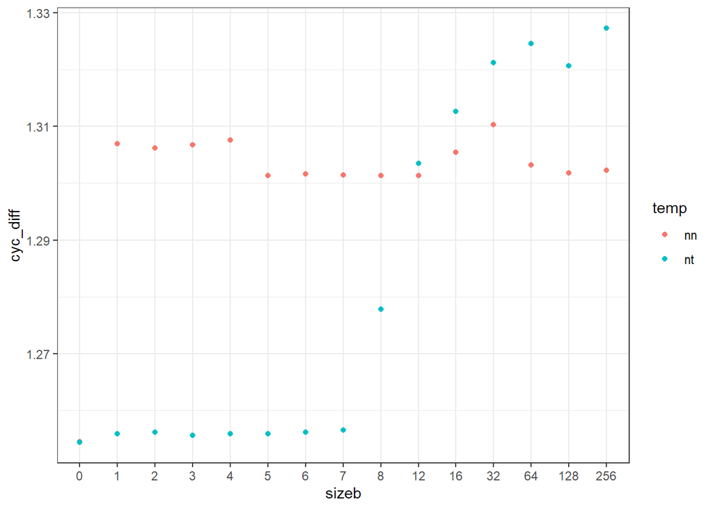

```r
 k_diff %>% filter(sizea==256, temp=="nt" | temp=="nn") %>% ungroup() %>% select(sizeb,cyc_diff,temp) %>% ggplot(aes(x=as.factor(sizeb), y=cyc_diff, color=temp)) + geom_point() +
   theme_bw() + xlab("sizeb") #+ geom_hline(yintercept=1)
```

Então parece que quando eu tenho uma thread só indo na memória, quando ela passa de temporal pra não temporal fica 25% mais lenta, mas se também tem outra thread indo na memória, fica em torno de 30% de diferença.

Fazendo uma análise conservadora e multiplicando os ciclos das aplicações com load não temporal por 0.8:

```r
k_corr <- k %>% transform(cyc=ifelse(temp=="nt" | temp=="nn", cyc*(0.8), cyc))
```

E repetindo a análise de antes até chegar na diferença de ciclos da soma das aplicações:

```r
ktemp <- k_corr %>% filter(sizeb != 0);
k_inv <- ktemp;
k_inv$sizea = ktemp$sizeb
k_inv$sizeb = ktemp$sizea
k_inv$temp <- replace(as.character(k_inv$temp), k_inv$temp == "nt","tmp")
k_inv$temp <- replace(as.character(k_inv$temp), k_inv$temp == "tn","nt")
k_inv$temp <- replace(as.character(k_inv$temp), k_inv$temp == "tmp","tn")
rm(ktemp)

k_corr_diff <- k_corr %>% group_by(sizea) %>% mutate_each(funs(./.[4]), cyc_diff=cyc, l3r_diff=l3r, l3m_diff=l3m, -sizeb)

k_corr_sum <- rbind(k_corr,k_inv)
k_corr_sum <- k_corr_sum %>% group_by(sizea,sizeb,temp) %>% summarise(cyc=sum(cyc), l3m=sum(l3m), l3r=sum(l3r), .groups='drop')
rm(k_inv)

k_corr_sum_diff <- k_corr_sum %>% group_by(sizea) %>% mutate_each(funs(./.[4]), cyc_diff=cyc, l3r_diff=l3r, l3m_diff=l3m, -sizeb)
k_corr_sum_diff %>% arrange(cyc_diff) #%>% head()
```

```
## # A tibble: 840 x 9
## # Groups:   sizea [14]
##    sizea sizeb temp         cyc       l3m        l3r cyc_diff l3r_diff l3m_diff
##    <dbl> <dbl> <chr>      <dbl>     <dbl>      <dbl>    <dbl>    <dbl>    <dbl>
##  1     8     0 tn    4775711654   8790854  919309255    0.992     1.00    0.862
##  2    32     0 tn    4862898142 234157290  290523125    0.999     1.00    1.00
##  3    12     0 tn    4929112452 180823041  462943778    1.00      1.00    1.00
##  4   256     0 tn    4948380790 252155587  252163055    1.00      1.00    1.00
##  5   128     0 tn    4912307273 250149731  252186289    1.00      1.00    1.00
##  6     7     0 tn    5434345105    174827 1126152972    1.00      1.00    0.957
##  7     5     0 tn    5009177553     97417 1038493458    1.00      1.00    0.996
##  8     3     0 tn    4953188766     53963 1032193283    1.00      1.00    1.00
##  9     2     0 tn    5031351329     35259 1048577101    1.00      1.00    0.995
## 10     1     0 tn    5030942956     17171 1048576997    1.00      1.00    1.00
## # ... with 830 more rows
```

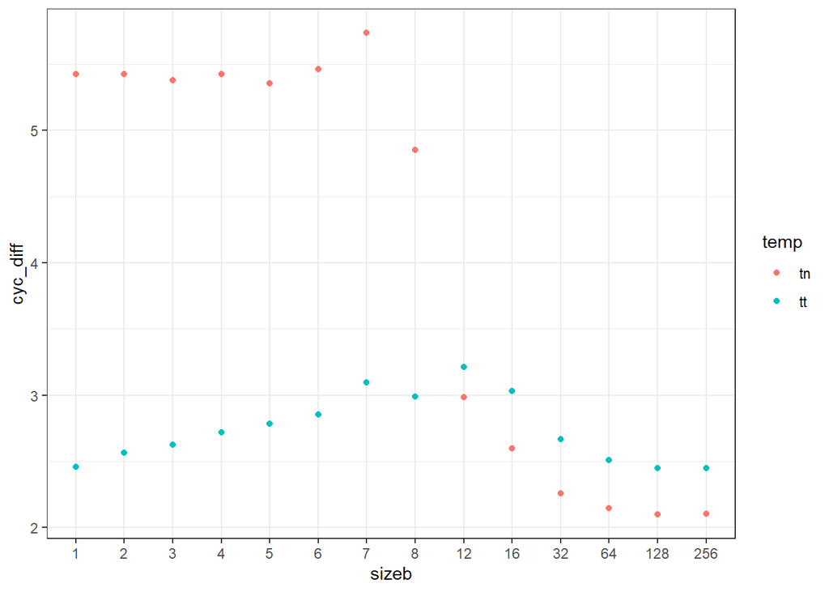

```r
k_corr_sum_diff %>% filter(sizea==8, temp == "tt" | temp == "tn") %>% ungroup() %>% filter(sizeb!=0) %>% select(sizeb,cyc_diff,temp) %>% ggplot(aes(x=as.factor(sizeb), y=cyc_diff, color=temp)) + geom_point() +
   theme_bw() + xlab("sizeb") # + geom_hline(yintercept=1)
```

Há ganhos para aplicação de 8 MB quando a segunda aplicação tem a partir de 12 MB.

Como são os ganhos para segunda aplicação não temporal de 256 MB de acordo com o tamanho da primeira aplicação?

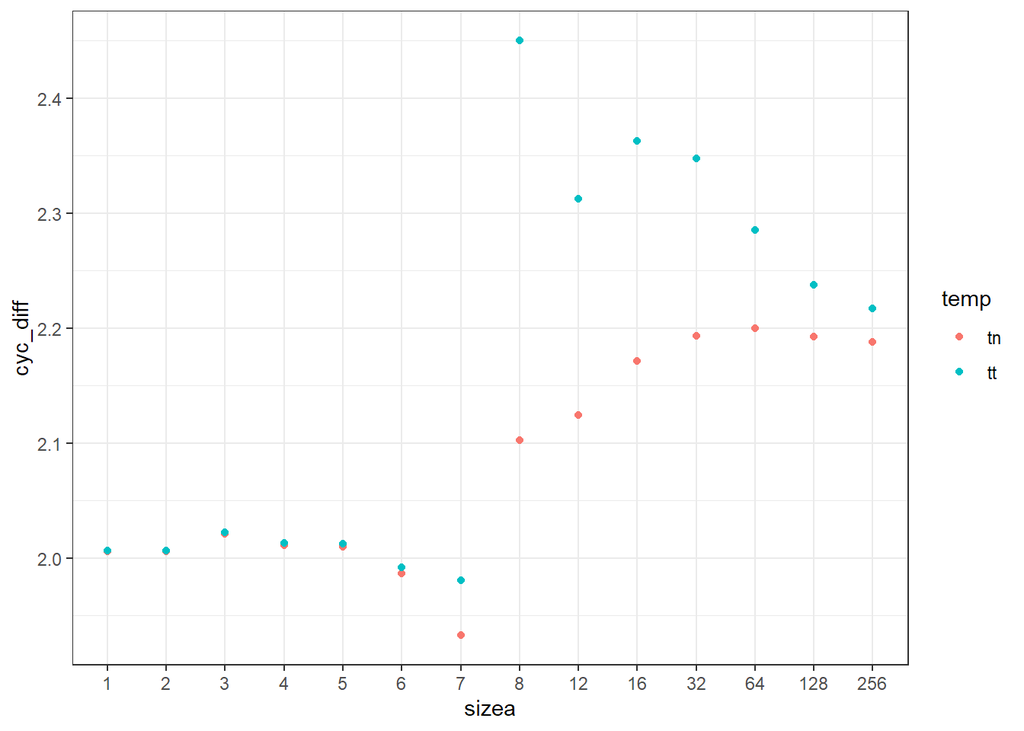

```r
k_corr_sum_diff %>% filter(sizeb==256, temp == "tt" | temp == "tn") %>% ungroup() %>% select(sizea,cyc_diff,temp) %>% ggplot(aes(x=as.factor(sizea), y=cyc_diff, color=temp)) + geom_point() +
   theme_bw() + xlab("sizea") #+ geom_hline(yintercept=1)
```

Tem mais ganho para 8 MB mesmo, mas também algum ganho significativo até 32 MB.

Mas sei lá também… não dá pra confiar muito nesses resultados de tanto de gambiarra que eu tive que fazer.